## MA2102

# Probability and Statistics

#### Lecture-24

## Student-t Distribution:

Let $X,Y$ are two independent random variables, $X\sim N(0,1)$, & $Y\sim \chi^2_n$, then $T=\frac{X}{\sqrt{\frac{Y}{n}}}=\frac{\sqrt{n}X}{\sqrt{Y}}$ is said to have a **student-t** distribution on $n-$degrees of freedom.

$f_X(x)=\frac{1}{\sqrt{2\pi}}e^{-\frac{x^2}{2}}$,$-\infty<x<\infty$, $f_Y(y)=\frac{1}{2^{\frac{n}{2}}\Gamma{\left(\frac{n}{2}\right)}}y^{\frac{n}{2}-1}e^{-\frac{y}{2}}$, $y>0$

The $JPDF$ of $X,Y$, $f_{X,Y}(x,y)=f_X(x)f_Y(y)$ ($\because$ $X,Y$ are independent)

$f_{X,Y}(x,y)=\frac{1}{2^{\frac{n+1}{2}}\sqrt{\pi}~\Gamma{\left(\frac{n}{2}\right)}}y^{\frac{n}{2}-1}e^{-\frac{1}{2}(y+x^2)}$,$-\infty<x<\infty,y>0$

consider, $T=\frac{\sqrt{n}X}{\sqrt{Y}}$, $U=Y$

$t=\frac{\sqrt{n}x}{\sqrt{y}}$, $u=y\implies~x=t\sqrt{\frac{u}{n}}$ & $y=u$

$\frac{\partial(x,y)}{\partial(t,u)}=\begin{vmatrix} \frac{\partial x}{\partial t} & \frac{\partial x}{\partial u} \\ \frac{\partial y}{\partial t} & \frac{\partial y}{\partial u} \end{vmatrix}=\sqrt{\frac{u}{n}}$

$JPDF$ of $(T,U)$, $f_{T,U}(t,u)=f_{X,Y}(t\sqrt{\frac{u}{n}},u)\begin{vmatrix}\frac{\partial(x,y)}{\partial(t,u)}\end{vmatrix}$, $t\in\mathbb{R},u>0$

$=\frac{1}{2^{\frac{n+1}{2}}\sqrt{\pi}~\Gamma{\left(\frac{n}{2}\right)}}u^{\frac{n}{2}-1}e^{-\frac{1}{2}(u+t^2\left(\frac{u}{n}\right))}\left(\sqrt{\frac{u}{n}}\right)$

$f_{T,U}(t,u)=\frac{1}{2^{\frac{n+1}{2}}\sqrt{n}\sqrt{\pi}~\Gamma{\left(\frac{n}{2}\right)}}e^{-\frac{u}{2}\left(1+\frac{t^2}{n}\right)}u^{\frac{n+1}{2}-1}$, $-\infty<t<\infty,u>0$

$PDF$ of $T$, $f_T(t)=\int_{-\infty}^{\infty}f_{T,U}(t,u)du$

$f_T(t)=\frac{1}{\sqrt{n}~2^{\frac{n+1}{2}}\sqrt{\pi}~\Gamma{\left(\frac{n}{2}\right)}}\int_{0}^{\infty}e^{-\frac{u}{2}\left(1+\frac{t^2}{n}\right)}u^{\frac{n+1}{2}-1}du$

take $s=\frac{u}{2}\left(1+\frac{t^2}{n}\right)\implies ds=\frac{1}{2}\left(1+\frac{t^2}{n}\right)du$, and $u=\frac{2s}{1+\frac{t^2}{n}}$

$f_T(t)=\frac{1}{\sqrt{n}~2^{\frac{n+1}{2}}\sqrt{\pi}~\Gamma{\left(\frac{n}{2}\right)}}\int_{0}^{\infty}e^{-s}\left({\frac{2s}{1+\frac{t^2}{n}}}\right)^{\frac{n+1}{2}-1}\frac{ds}{\frac{1}{2}\left(1+\frac{t^2}{n}\right)}$

$=\frac{2^{\frac{n+1}{2}}}{\sqrt{n}~2^{\frac{n+1}{2}}\sqrt{\pi}~\Gamma{\left(\frac{n}{2}\right)}\left(1+\frac{t^2}{n}\right)^{\frac{n+1}{2}}}\int_{0}^{\infty}e^{-s}{s}^{\frac{n+1}{2}-1}ds$

$=\frac{1}{\sqrt{n}\sqrt{\pi}~\Gamma{\left(\frac{n}{2}\right)}\left(1+\frac{t^2}{n}\right)^{\frac{n+1}{2}}}\Gamma{\left(\frac{n+1}{2}\right)}$

$=\frac{\Gamma{\left(\frac{n}{2}+\frac{1}{2}\right)} \left(1+\frac{t^2}{n}\right)^{-\frac{n+1}{2}}}{\sqrt{n}~\Gamma{\left(\frac{1}{2}\right)}~\Gamma{\left(\frac{n}{2}\right)}}$

$f_T(t)=\frac{ 1}{\sqrt{n}~B\left(\frac{n}{2},\frac{1}{2}\right)}\left(1+\frac{t^2}{n}\right)^{-\frac{n+1}{2}}$, $-\infty<t<\infty$

**Notation:** $T\sim t_n$

**Properties:**

1. $f_T$ is symmetric about $0$ (i.e $f_T(-t)=f_T(t)$)
1. for n=1 $f_T(t)=\frac{1}{{\pi}{\left(1+{t^2}\right)}}$, $-\infty<t<\infty$ ($\because B\left(\frac{1}{2},\frac{1}{2}\right)=\pi$)  
   $T$ follows Cauchy distribution, and we know that Expectation do not exists for Cauchy distribution.
1. for $n\ge 2$, $E(T)=E\left(\frac{X}{\sqrt{\frac{Y}{n}}}\right)=E(X)E\left(\frac{1}{\sqrt{\frac{Y}{n}}}\right)=0$ ($\because~X,Y$ are independent and $E(X)=0$

$Var(T)=E(T^2)$ ($\because E(T)=0$)

$=E\left(\frac{X^2}{\frac{Y}{n}}\right)=E(X^2)E\left(\frac{n}{Y}\right)=1\times n E\left(\frac{1}{Y}\right)=\frac{n}{n-2}$

$\left(\because E\left(\frac{1}{Y}\right)=\int_{0}^{\infty}\frac{1}{y}\frac{1}{2^{\frac{n}{2}}\Gamma{\left(\frac{n}{2}\right)}}y^{\frac{n}{2}-1}e^{-\frac{y}{2}}dy=\frac{1}{\frac{2(n-2)}{2}}\int_{0}^{\infty}\frac{1}{2^{\frac{n-2}{2}}\Gamma{\left(\frac{n-2}{2}\right)}}y^{\frac{n-2}{2}-1}e^{-\frac{y}{2}}dy= \frac{1}{n-2}\times 1 \right)$

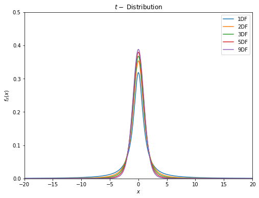

```python
import math
import numpy as np
import matplotlib.pyplot as plt
import scipy.special as sc
%matplotlib inline

Infty=20
t=np.linspace(-Infty,Infty,1000)
plt.figure(figsize=(8,6))
dfs = [1,2,3,5,9] # degree of freedoms
for n in dfs:
    # ploting thw pdf of Student-t distribution with n degrees of freedom
    plt.plot(t,(1/(math.sqrt(n)*sc.beta(n/2,1/2)))*(1+(t**2)/n)**(-(n+1)/2),label=r"{0}DF".format(n))
plt.legend(loc='upper right')
plt.title(r"$t-$ Distribution")
plt.xlabel("$x$")
plt.ylabel("$f_X(x)$")
plt.xlim(-20,20)
plt.ylim(0,0.5)
plt.show()
```

$CDF$, of $T\sim t_n$, $F_T(x)=P(T\le x)=\int_{-\infty}^{x}\frac{ 1}{\sqrt{n}~B\left(\frac{n}{2},\frac{1}{2}\right)}\left(1+\frac{t^2}{n}\right)^{-\frac{n+1}{2}}dt$

```python
%matplotlib inline
import math
import numpy as np
import matplotlib.pyplot as plt
from ipywidgets import interact ,interactive, fixed, interact_manual
import ipywidgets as widgets
from scipy import stats as st

Infty =15

def AreaUnderStudent_t_PDF(n,x):
    fig, ax = plt.subplots(figsize=(12,8))

    xx=np.linspace(-Infty,Infty,1000)
    T=st.t(n)  # Student-t random variable with n degrees of freedom from scipy.stats
    ax.plot(xx,T.pdf(xx),label=r"{0}DF".format(n)) # poting graph of pdf

    xx=list(np.linspace(-Infty,x,1000))

    ax.fill_between(xx,0,T.pdf(xx),color='g',label=r'$F_T(%s)=%s$'%(x,round(T.cdf(x),4)))
    ax.set_title(r"AREA UNDER THE $t_{n}$ PDF CURVE TO THE LEFT OF $x$" )
    ax.set_xlabel(r"$t$")
    ax.set_ylabel(r"$f_{T}(t)$")
    ax.text(x,-0.02,r'%s'%(x))
    ax.set_xticks([-15,0,15])
    ax.set_xlim(-Infty,Infty)
    ax.set_ylim(0,0.5)
    ax.legend()
    plt.show()

# Please Click the Run Interact Button to see the Bar graph
interactive(AreaUnderStudent_t_PDF,{'manual':False},n=widgets.IntSlider(min=1, max=50, step=1, value=3,description='$n$ :'),x=widgets.FloatSlider(min=-Infty, max=Infty, step=0.01, value=2,description='$x$ :'))
```

For $0< \alpha <1$, the number $x\in \mathbb{R}$ such that $P(t_n>x)=\alpha$ is denoted by $t_{\alpha,n}$, and to find these $t_{\alpha,n}$ values one has to either use software or refer to t-distribution Table (Which can be found any statistics book)  
By symmetry we can see that $P(t_n\le -t_{\alpha,n})=\alpha\implies 1-P(t_n>-t_{\alpha,n})=\alpha\implies P(t_n>-t_{\alpha,n})=1-\alpha$  
Hence we have, $-t_{\alpha,n}=t_{1-\alpha,n}$

```python
%matplotlib inline
import math
import numpy as np
import matplotlib.pyplot as plt
from ipywidgets import interact ,interactive, fixed, interact_manual
import ipywidgets as widgets
from scipy import stats as st

Infty =15

def t_alpha_n(n,alpha):
    fig, ax = plt.subplots(figsize=(12,8))
    T=st.t(n)  # Student-t random variable with n degrees of freedom from scipy.stats
    x=np.linspace(-Infty,Infty,1000)

    ax.plot(x,T.pdf(x),label=r"{0}DF".format(n)) # poting graph of pdf


    xx=np.linspace(T.ppf(1-alpha),Infty,1000)
    ax.fill_between(xx,0,T.pdf(xx),color='y',label=r'$\alpha=%s$'%(round(alpha,4)))

    # X.ppf(p) returns pth quantile of X
    ax.scatter([T.ppf(1-alpha)],[0],s=10,color=(1,0,0),label=r'$t_{%s,%s}=%s$'%(alpha,n,round(T.ppf(1-alpha),3)))
    ax.set_title(r"AREA UNDER THE $t_{n}$ PDF CURVE TO THE right OF $t_{\alpha,n}$" )
    ax.set_xlabel(r"$t$")
    ax.set_ylabel(r"$f_X(t)$")
    ax.set_xlim(-Infty,Infty)
    ax.set_xticks([-15,0,15])
    ax.set_ylim(0,0.5)
    ax.text(T.ppf(1-alpha),-0.02,r'$t_{%s,%s}$'%(round(alpha,4),n),color=(0,0,1))
    ax.legend()
    plt.show()

# Please Click the Run Interact Button to see the Bar graph
interactive(t_alpha_n,{'manual':False},n=widgets.IntSlider(min=1, max=50, step=1, value=3,description='$n$ :'),alpha=widgets.FloatSlider(min=0, max=0.2, step=0.01, value=0.1,description=r'$\alpha$ :'))
```

```python
%matplotlib inline
import math
import numpy as np
from IPython.display import display, Markdown,HTML
from scipy import stats as st

def printLine(n):
    sline=""
    for _ in range(n):
        sline=sline+"-"
    display(HTML('<span style="color:blue">{0}</span>'.format(sline)))

nn=[r for r in range(1,31) ]
alphas=[0.10,0.05,0.025,0.01,0.005]
display(Markdown("&nbsp; "*30+"**$t_{\\alpha,n}$  Table**"))
printLine(100)
s="n "
for a in alphas:
    s=s+"&nbsp; "*6+r"$\alpha$="+str(a)
display(Markdown(s))
printLine(100)
for n in nn:
    T=st.t(n)
    s=str(n)
    for a in alphas:
        ss=str(round(T.ppf(1-a),3))

        ss=ss+(6-len(str(ss)))*'0'
        s= s+"&nbsp; "*7+ss
    display(Markdown(s))

printLine(100)
```

**$t_{\alpha,n}$ Table**

----------------------------------------------------------------------------------------------------

n $\alpha$=0.1 $\alpha$=0.05 $\alpha$=0.025 $\alpha$=0.01 $\alpha$=0.005

----------------------------------------------------------------------------------------------------

1 3.0780 6.3140 12.706 31.821 63.657

2 1.8860 2.9200 4.3030 6.9650 9.9250

3 1.6380 2.3530 3.1820 4.5410 5.8410

4 1.5330 2.1320 2.7760 3.7470 4.6040

5 1.4760 2.0150 2.5710 3.3650 4.0320

6 1.4400 1.9430 2.4470 3.1430 3.7070

7 1.4150 1.8950 2.3650 2.9980 3.4990

8 1.3970 1.8600 2.3060 2.8960 3.3550

9 1.3830 1.8330 2.2620 2.8210 3.2500

10 1.3720 1.8120 2.2280 2.7640 3.1690

11 1.3630 1.7960 2.2010 2.7180 3.1060

12 1.3560 1.7820 2.1790 2.6810 3.0550

13 1.3500 1.7710 2.1600 2.6500 3.0120

14 1.3450 1.7610 2.1450 2.6240 2.9770

15 1.3410 1.7530 2.1310 2.6020 2.9470

16 1.3370 1.7460 2.1200 2.5830 2.9210

17 1.3330 1.7400 2.1100 2.5670 2.8980

18 1.3300 1.7340 2.1010 2.5520 2.8780

19 1.3280 1.7290 2.0930 2.5390 2.8610

20 1.3250 1.7250 2.0860 2.5280 2.8450

21 1.3230 1.7210 2.0800 2.5180 2.8310

22 1.3210 1.7170 2.0740 2.5080 2.8190

23 1.3190 1.7140 2.0690 2.5000 2.8070

24 1.3180 1.7110 2.0640 2.4920 2.7970

25 1.3160 1.7080 2.0600 2.4850 2.7870

26 1.3150 1.7060 2.0560 2.4790 2.7790

27 1.3140 1.7030 2.0520 2.4730 2.7710

28 1.3130 1.7010 2.0480 2.4670 2.7630

29 1.3110 1.6990 2.0450 2.4620 2.7560

30 1.3100 1.6970 2.0420 2.4570 2.7500

----------------------------------------------------------------------------------------------------

## $F$-distribution:

Let $X\sim \chi^2_n$, $Y\sim \chi^2_m$ are two independent random variables, then $U=\frac{\frac{X}{n}}{{\frac{Y}{m}}}=\frac{mX}{nY}$ is said to have a **$F-$** distribution on $n$, and $m$ degrees of freedom.

$f_X(x)=\frac{1}{2^{\frac{n}{2}}\Gamma{\left(\frac{n}{2}\right)}}x^{\frac{n}{2}-1}e^{-\frac{x}{2}}$, $x>0$

$f_Y(y)=\frac{1}{2^{\frac{m}{2}}\Gamma{\left(\frac{m}{2}\right)}}y^{\frac{m}{2}-1}e^{-\frac{y}{2}}$, $y>0$

$JPDF$ of $(X,Y)$, $f_{X,Y}(x,y)=f_X(x)f_Y(y)$ ($\because$ $X,Y$ are independent)

$f_{X,Y}(x,y)=\frac{1}{2^{\frac{n+m}{2}}\Gamma{\left(\frac{n}{2}\right)}\Gamma{\left(\frac{m}{2}\right)}}x^{\frac{n}{2}-1}y^{\frac{m}{2}-1}e^{-\frac{x+y}{2}}$, $x>0,y>0$

consider, $U=\frac{mX}{nY}$, $V=Y$

$u=\frac{mx}{ny}$, $v=y\implies x=\frac{nuv}{m},y=v$

$\frac{\partial(x,y)}{\partial(u,v)}=\begin{vmatrix} \frac{\partial x}{\partial u} & \frac{\partial x}{\partial v} \\ \frac{\partial y}{\partial u} & \frac{\partial y}{\partial v} \end{vmatrix}=\begin{vmatrix} \frac{nv}{m} & \frac{nu}{m} \\ 0 & 1 \end{vmatrix}=\frac{nv}{m}$

$f_{U,V}(u,v)=f_{X,Y}(\frac{nuv}{m},v)\begin{vmatrix}\frac{\partial(x,y)}{\partial(u,v)}\end{vmatrix}$

$f_{U,V}(u,v)=\frac{1}{2^{\frac{n+m}{2}}\Gamma{\left(\frac{n}{2}\right)}\Gamma{\left(\frac{m}{2}\right)}}{\left(\frac{nuv}{m}\right)}^{\frac{n}{2}-1}v^{\frac{m}{2}-1}e^{-\frac{\frac{nuv}{m}+v}{2}} \begin{vmatrix}\frac{nv}{m}\end{vmatrix}$

$f_{U,V}(u,v)=\frac{\left(\frac{n}{m}\right)^{\frac{n}{2}}}{2^{\frac{n+m}{2}}\Gamma{\left(\frac{n}{2}\right)}\Gamma{\left(\frac{m}{2}\right)}}{v}^{\frac{n+m}{2}-1}{u^{\frac{n}{2}-1}}e^{-\frac{v}{2}(\frac{nu}{m}+1)}$, $u>0,v>0$

$PDF$ of $U$, $f_U(u)=\int_{-\infty}^{\infty}f_{U,V}(u,v)dv$

$f_U(u)=\frac{\left(\frac{n}{m}\right)^{\frac{n}{2}}u^{\frac{n}{2}-1}}{{2^{\frac{n+m}{2}}\Gamma{\left(\frac{n}{2}\right)}\Gamma{\left(\frac{m}{2}\right)}}}\int_{0}^{\infty}{v}^{\frac{n+m}{2}-1}e^{-\frac{v}{2}(\frac{nu}{m}+1)}dv$

take $t=\frac{v}{2}(\frac{nu}{m}+1)\implies dt=\frac{1}{2}(\frac{nu}{m}+1)dv$

$f_U(u)=\frac{\left(\frac{n}{m}\right)^{\frac{n}{2}}u^{\frac{n}{2}-1}}{{2^{\frac{n+m}{2}}\Gamma{\left(\frac{n}{2}\right)}\Gamma{\left(\frac{m}{2}\right)}}}\int_{0}^{\infty}{\left({\frac{2t}{\left(\frac{nu}{m}+1\right)}}\right)}^{\frac{n+m}{2}-1}e^{-t}\frac{2dt}{(\frac{nu}{m}+1)}$

$=\frac{\left(\frac{n}{m}\right)^{\frac{n}{2}}u^{\frac{n}{2}-1}}{{\Gamma{\left(\frac{n}{2}\right)}\Gamma{\left(\frac{m}{2}\right)} {\left(\frac{nu}{m}+1\right)}^{\frac{n+m}{2}} }}\int_{0}^{\infty}{t}^{\left(\frac{n}{2}+\frac{m}{2}\right)-1}e^{-t}{dt}$

$=\frac{\left(\frac{n}{m}\right)^{\frac{n}{2}}u^{\frac{n}{2}-1}}{\Gamma{\left(\frac{n}{2}\right)}\Gamma{\left(\frac{m}{2}\right)} {\left(\frac{nu}{m}+1\right)}^{\frac{n+m}{2}} }\Gamma\left(\frac{n}{2}+\frac{m}{2}\right)$

$f_U(u)=\left\{\begin{matrix} \frac{\left(\frac{n}{m}\right)^{\frac{n}{2}}u^{\frac{n}{2}-1}}{{B{\left(\frac{n}{2},\frac{m}{2}\right)} {\left(\frac{nu}{m}+1\right)}^{\frac{n+m}{2}} }}& u>0\\ &\\ 0& u\le 0 \end{matrix}\right.$

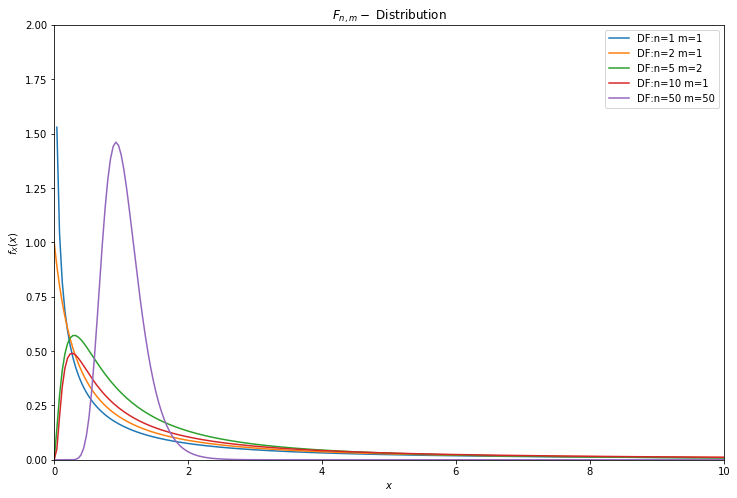

```python
import math
import numpy as np
import matplotlib.pyplot as plt
import scipy.special as sc
from scipy import stats as st
%matplotlib inline

def f(t):
    return (((n/m)**(n/2))*(t**(n/2-1)))/((sc.beta(n/2,m/2))*(((n*t)/m +1)**((m+n)/2)))
Infty=40
np.seterr(divide = 'ignore')
t=np.linspace(0,Infty,1000)
plt.figure(figsize=(12,8))
dfs = [(1,1),(2,1),(5,2),(10,1),(50,50)] # degree of freedoms
for n,m in dfs:
    # ploting the pdf of F distribution with n,m degrees of freedom
    plt.plot(t,f(t),label=r"DF:n={0} m={1}".format(n,m))
plt.legend(loc='upper right')
plt.title(r"$F_{n,m}-$ Distribution")
plt.xlabel("$x$")
plt.ylabel("$f_X(x)$")
plt.xlim(0,10)
plt.ylim(0,2)
plt.show()
```

**Notation:** $U\sim F_{n,m}$

$CDF$ of $U$, $F_U(x)=P(U\le x)=\int_{0}^{x} \frac{\left(\frac{n}{m}\right)^{\frac{n}{2}}t^{\frac{n}{2}-1}}{{B{\left(\frac{n}{2},\frac{m}{2}\right)} {\left(\frac{nt}{m}+1\right)}^{\frac{n+m}{2}} }}dt$

```python
%matplotlib inline
import math
import numpy as np
import matplotlib.pyplot as plt
from ipywidgets import interact ,interactive, fixed, interact_manual
import ipywidgets as widgets
from scipy import stats as st

Infty =15

def AreaUnderStudent_Fnm_PDF(n,m,x):
    fig, ax = plt.subplots(figsize=(12,8))

    xx=np.linspace(0,Infty,1000)
    F=st.f(n,m)  # F random variable with n,m degrees of freedom from scipy.stats
    ax.plot(xx,F.pdf(xx),label=r"DF: n={0} m={1}".format(n,m)) # poting graph of pdf

    xx=list(np.linspace(0,x,1000))

    ax.fill_between(xx,0,F.pdf(xx),color='g',label=r'$F_U(%s)=%s$'%(x,round(F.cdf(x),4)))
    ax.set_title(r"AREA UNDER THE $F_{n,m}$ PDF CURVE TO THE LEFT OF $x$" )
    ax.set_xlabel(r"$t$")
    ax.set_ylabel(r"$f_{U}(t)$")
    ax.text(x,-0.06,r'%s'%(x))
    ax.set_xticks([0,25])
    ax.set_xlim(0,Infty)
    ax.set_ylim(0,2)
    ax.legend()
    plt.show()

# Please Click the Run Interact Button to see the Bar graph
n=widgets.IntSlider(min=1, max=50, step=1, value=3,description='$n$ :')
m=widgets.IntSlider(min=1, max=50, step=1, value=3,description='$m$ :')
x=widgets.FloatSlider(min=0, max=Infty, step=0.01, value=2,description='$x$ :')
interactive(AreaUnderStudent_Fnm_PDF,{'manual':False},n=n,m=m,x=x)
```

$E(U)=E\left(\frac{mX}{nY}\right)=\frac{m}{n}E\left(\frac{X}{Y}\right)=\frac{m}{n}E(X)E\left(\frac{1}{Y}\right)=\frac{m}{n}\times n\times \frac{1}{m-2}=\frac{m}{m-2}$ ($\because~X,Y$ are independent and $E(X)=E(\chi^2_n)=n$)

$\left(\because E\left(\frac{1}{Y}\right)=\int_{0}^{\infty}\frac{1}{y}\frac{1}{2^{\frac{m}{2}}\Gamma{\left(\frac{m}{2}\right)}}y^{\frac{m}{2}-1}e^{-\frac{y}{2}}dy=\frac{1}{\frac{2(m-2)}{2}}\int_{0}^{\infty}\frac{1}{2^{\frac{m-2}{2}}\Gamma{\left(\frac{m-2}{2}\right)}}y^{\frac{m-2}{2}-1}e^{-\frac{y}{2}}dy= \frac{1}{m-2}\times 1 \right)$

$E(U^2)=E\left(\frac{m^2X^2}{n^2Y^2}\right)=\frac{m^2}{n^2}E\left(\frac{X^2}{Y^2}\right)=\frac{m^2}{n^2}E(X^2)E\left(\frac{1}{Y^2}\right)=\frac{m^2}{n^2}\times (2n+n^2)\times \frac{1}{(m-2)(m-4)}=\frac{m^2(2+n)}{n(m-2)(m-4)}$  
($\because~X,Y$ are independent and $E(X^2)=Var(X)+(E(X))^2=Var(\chi^2_n)+E(\chi^2_n)^2=2n+n^2$)

$\left(\because E\left(\frac{1}{Y^2}\right)=\int_{0}^{\infty}\frac{1}{y^2}\frac{1}{2^{\frac{m}{2}}\Gamma{\left(\frac{m}{2}\right)}}y^{\frac{m}{2}-1}e^{-\frac{y}{2}}dy=\frac{1}{\frac{4(m-2)(m-4)}{4}}\int_{0}^{\infty}\frac{1}{2^{\frac{m-4}{2}}\Gamma{\left(\frac{m-4}{2}\right)}}y^{\frac{m-4}{2}-1}e^{-\frac{y}{2}}dy= \frac{1}{(m-2)(m-4)}\times 1 \right)$

$Var(U)=E(U^2)-(E(U))^2=\frac{m^2(2+n)}{n(m-2)(m-4)}-\frac{m^2}{(m-2)^2}=\frac{2m^2(m+n-2)}{n(m-2)^2(m-4)}$

For $0< \alpha <1$, the number $x\in \mathbb{R}$ such that $P(F_{n,m}>x)=\alpha$ is denoted by $F_{\alpha,n,m}$, and to find these $F_{\alpha,n,m}$ values one has to either use software or refer to F-distribution Table (Which can be found any statistics book)

**Note:**  
1. $ F_{1-\alpha,m,n}=\frac{1}{F_{\alpha,n,m}}$

*proof:* $P(F_{n,m}>F_{\alpha,n,m})=\alpha$

$P(\frac{mX}{nY}>F_{\alpha,n,m})=\alpha$ where $X\sim \chi^2_n,Y\sim \chi^2_m$ and $F_{n,m}=\frac{mX}{nY}$

$P(\frac{nY}{mX}<\frac{1}{F_{\alpha,n,m}})=\alpha$

$P(F_{m,n}<\frac{1}{F_{\alpha,n,m}})=\alpha$ ($\because F_{m,n}=\frac{nY}{mX}$ ) where $X\sim \chi^2_n,Y\sim \chi^2_m$

$1-P(F_{m,n}\ge \frac{1}{F_{\alpha,n,m}})=\alpha\implies P(F_{m,n}\ge \frac{1}{F_{\alpha,n,m}})=1-\alpha$

$\therefore F_{1-\alpha,m,n}=\frac{1}{F_{\alpha,n,m}}$

1. If $X\sim t_m\implies X^2\sim F_{1,m}$

*proof:* $X=\frac{Z}{\sqrt{\frac{\chi^2_m}{m}}}\implies X^2=\frac{Z^2}{\frac{\chi^2_m}{m}}=\frac{\frac{\chi^2_1}{1}}{\frac{\chi^2_m}{m}}\sim F_{1,m}$

```python
%matplotlib inline
import math
import numpy as np
import matplotlib.pyplot as plt
from ipywidgets import interact ,interactive, fixed, interact_manual
import ipywidgets as widgets
from scipy import stats as st

Infty =15

def Fnm_alpha(n,m,alpha):
    fig, ax = plt.subplots(figsize=(12,8))
    F=st.f(n,m)  # F random variable with n degrees of freedom from scipy.stats
    x=np.linspace(0,Infty,1000)

    ax.plot(x,F.pdf(x),label=r"DF:n={0} m={1}".format(n,m)) # poting graph of pdf


    xx=np.linspace(F.ppf(1-alpha),Infty,1000)
    ax.fill_between(xx,0,F.pdf(xx),color='y',label=r'$\alpha=%s$'%(round(alpha,4)))

    # X.ppf(p) returns pth quantile of X
    ax.scatter([F.ppf(1-alpha)],[0],s=10,color=(1,0,0),label=r'$F_{%s,%s,%s}=%s$'%(alpha,n,m,round(F.ppf(1-alpha),3)))
    ax.set_title(r"AREA UNDER THE $F_{n,m}$ PDF CURVE TO THE right OF $F_{\alpha,n,m}$" )
    ax.set_xlabel(r"$t$")
    ax.set_ylabel(r"$f_X(t)$")
    ax.set_xlim(0,Infty)
    ax.set_xticks([0,15])
    ax.set_ylim(0,2)
    ax.text(F.ppf(1-alpha),-0.06,r'$F_{%s,%s,%s}$'%(round(alpha,4),n,m),color=(0,0,1))
    ax.legend()
    plt.show()

n=widgets.IntSlider(min=1, max=50, step=1, value=3,description='$n$ :')
m=widgets.IntSlider(min=1, max=50, step=1, value=3,description='$m$ :')
alpha=widgets.FloatSlider(min=0, max=0.2, step=0.01, value=0.1,description=r'$\alpha$ :')
# Please Click the Run Interact Button to see the Bar graph
interactive(Fnm_alpha,{'manual':False},n=n,m=m,alpha=alpha)
```

## Sampling Distributions

**Population:** A population is a collection of measurements

**Sample:** A subset of a population

**Random Sample:** Let $X_1,X_2,...,X_n$ i.i.d random variables with $CDF$ $F(x)$ is called a random sample of size $n$ from the population with $CDF$ $F(x)$

**Statistic:** Let $X_1,X_2,...,X_n$ be a random sample, then a function of random sample $T=T(X_1,X_2,...,X_n)$ is called a statistic.

**Examples:**

1. Sample mean: $\overline{X}=\frac{1}{n}\sum_{i=1}^nX_i$
1. Sample variance: $S^2=\frac{1}{n-1}\sum_{i=1}^n(X_i-\overline{X})^2$
1. Sample median: $\left\{\begin{matrix} X_{\left(\frac{n+1}{2}\right)}& \text{if n is odd}\\ \frac{1}{2} \left( X_{\left(\frac{n}{2}\right)}+X_{\left(\frac{n}{2}+1\right)} \right)& \text{if n is even} \end{matrix}\right.$
1. Sample Range: $X_{(n)}-X_{(1)}$

**Theorem:** Let $X_1,X_2,...,X_n\overset{i.i.d}{\sim}N(\mu,\sigma^2)$, then $\frac{\sqrt{n}\left(\overline{X}-\mu\right)}{\sigma}\sim N(0,1)$ and $\frac{\sqrt{n}\left(\overline{X}-\mu\right)}{S}\sim t_{n-1}$

*proof:* First we know that any linear combinations of normal random variables again normal random variable, so $\overline{X}$ is normal for sure, and

$E(\overline{X})=E\left(\frac{1}{n}\sum_{i=1}^{n}X_i\right)=\frac{1}{n}\left(\sum_{i=1}^{n}E(X_i)\right)\frac{1}{n}\times n\mu=\mu$

$Var(\overline{X})=Var\left(\frac{1}{n}\sum_{i=1}^{n}X_i\right)=\frac{1}{n^2}\left(\sum_{i=1}^{n}Var(X_i)\right)\frac{1}{n^2}\times n\sigma^2=\frac{\sigma^2}{n}$, ($\because X_1,X_2,...,X_n$ are independent)

So, $\overline{X}\sim N(\mu,\frac{\sigma^2}{n})\implies \frac{\overline{X}-\mu}{\frac{\sigma}{\sqrt{n}}}\sim N(0,1)$

Hence $\frac{\sqrt{n}\left(\overline{X}-\mu\right)}{\sigma}\sim N(0,1)$

now, consider, $\sum_{i=1}^{n}\left(X_i-\mu\right)^2=\sum_{i=1}^{n}\left(X_i-\overline{X}+\overline{X}-\mu\right)^2$

$=\sum_{i=1}^{n}\left[(X_i-\overline{X})^2+(\overline{X}-\mu)^2+2(X_i-\overline{X})(\overline{X}-\mu)\right]$

$=\sum_{i=1}^{n}(X_i-\overline{X})^2+\sum_{i=1}^{n}(\overline{X}-\mu)^2+2(\overline{X}-\mu)\sum_{i=1}^{n}(X_i-\overline{X})$

$=\sum_{i=1}^{n}(X_i-\overline{X})^2+n(\overline{X}-\mu)^2+2(\overline{X}-\mu)\times 0$  
($\because~\sum_{i=1}^{n}(X_i-\overline{X})=\sum_{i=1}^{n}X_i-n\overline{X}=n\overline{X}-n\overline{X}=0$)

$\therefore $ $\sum_{i=1}^{n}\left(X_i-\mu\right)^2 =\sum_{i=1}^{n}(X_i-\overline{X})^2+\left(\sqrt{n}(\overline{X}-\mu)\right)^2$

$\therefore $ $\sum_{i=1}^{n}\left(\frac{X_i-\mu}{\sigma}\right)^2 =\sum_{i=1}^{n}\left(\frac{X_i-\overline{X}}{\sigma}\right)^2+\left(\frac{\sqrt{n}\left(\overline{X}-\mu\right)}{\sigma}\right)^2$

Here $\sum_{i=1}^{n}\left(\frac{X_i-\mu}{\sigma}\right)^2 \sim \chi^2_n$ ($\because~\frac{X_i-\mu}{\sigma}\sim N(0,1)$)

$\left(\frac{\sqrt{n}\left(\overline{X}-\mu\right)}{\sigma}\right)^2\sim \chi^2_1$ ($\because~ \frac{\sqrt{n}\left(\overline{X}-\mu\right)}{\sigma}\sim N(0,1)$)

$\implies \sum_{i=1}^{n}\left(\frac{X_i-\overline{X}}{\sigma}\right)^2\sim \chi^2_{n-1}$

Hence $ \sum_{i=1}^{n}\left(\frac{X_i-\overline{X}}{\sigma}\right)^2=\frac{(n-1)S^2}{\sigma^2}\sim \chi^2_{n-1}$

now, $\frac{\sqrt{n}\left(\overline{X}-\mu\right)}{S}=\frac{\frac{\sqrt{n}\left(\overline{X}-\mu\right)}{\sigma}}{\sqrt{\frac{(n-1)S^2}{\sigma^2 (n-1)}}}=\frac{\frac{\sqrt{n}\left(\overline{X}-\mu\right)}{\sigma}}{\sqrt{\frac{\frac{(n-1)S^2}{\sigma^2}}{(n-1)}}}\sim t_{n-1}$ ($\because~ \frac{\sqrt{n}\left(\overline{X}-\mu\right)}{\sigma}\sim N(0,1)$ and $\frac{(n-1)S^2}{\sigma^2} \sim \chi^2_{n-1}$ and $\overline{X}-\mu$, $S^2$ $\text{are independent}$)

**Note-1:** $\overline{X}-\mu$, $S^2$ are independent, when $X_1,X_2,...,X_n\overset{i.i.d}{\sim}N(\mu,\sigma^2)$

proof: $X_1,X_2,...,X_n\overset{i.i.d}{\sim}N(\mu,\sigma^2)$

$\overline{X}=\frac{1}{n}\sum_{i=1}^nX_i$, and $S^2=\frac{1}{n-1}\sum_{i=1}^n(X_i-\overline{X})^2$

We already know that $\overline{X}\sim N(\mu,\frac{\sigma^2}{n})$. So $\overline{X},X_i-\overline{X}$ follows Bivariate Normal distributions, so we can say that $Cov(\overline{X},X_i-\overline{X})=0\implies\overline{X},X_i-\overline{X}$ are independent.

$Cov(\overline{X},X_i-\overline{X})=Cov(\frac{1}{n}\sum_{j=1}^nX_j,X_i)-Cov(\overline{X},\overline{X})=\frac{1}{n}\left(\sum_{j=1}^nCov(X_j,X_i)\right)-Var(\overline{X})$

$=\frac{1}{n}\left(Cov(X_i,X_i)\right)-\frac{\sigma^2}{n}$ ($\because~Cov(X_j,X_i)=0$ for $i\ne j$)

$=\frac{1}{n}\left(\sigma^2\right)-\frac{\sigma^2}{n}=0$

i.e $\overline{X}$ is independent of $X_i-\overline{X}$ $\forall i=1,2,...,n$

$\implies$ $\overline{X}$ is independent of $\sum_{i=1}^{n}(X_i-\overline{X})^2$

Hence $\overline{X}$, $S^2$ are independent $\implies$ $\overline{X}-\mu$, $S^2$ are independent

**Note-2:**Let $X_1,X_2,...,X_m\overset{i.i.d}{\sim}N(\mu_X,\sigma^2_X)$, and Let $Y_1,Y_2,...,Y_n\overset{i.i.d}{\sim}N(\mu_Y,\sigma^2_Y)$, and let $S_X^2=\frac{1}{m-1}\sum_{i=1}^{m}(X_i-\overline{X})^2$, and $S_Y^2=\frac{1}{m-1}\sum_{i=1}^{m}(Y_i-\overline{Y})^2$, then $\frac{\sigma_Y^2S_X^2}{\sigma_X^2S_Y^2}\sim F_{m-1,n-1}$

*proof:* $\frac{\sigma_Y^2S_X^2}{\sigma_X^2S_Y^2}=\frac{\frac{\left({\frac{(m-1)S_X^2}{\sigma_X^2}}\right)}{m-1}}{\frac{\left({\frac{(n-1)S_Y^2}{\sigma_Y^2}}\right)}{n-1}}=\frac{\frac{\chi^2_{m-1}}{m-1}}{\frac{\chi^2_{n-1}}{n-1}}\sim F_{m-1,n-1}$

**Example:** Suppose scores on a $IQ$ test are normally distributed with a population mean of 100. and Suppose 20 people are randomly selected and tested. The standard deviation in the sample group is 15. What is the probability that the average test score in the sample group will be at most 110.

*solution:* Let $X_1,X_2,...,X_{20}$ represent (random sample) score of 20 people, here the random sample size $n=20$

$\overline{X}=\frac{1}{20}\sum_{i=1}^{20}X_i$, $s=15$, $\mu=100$

Let $T=\frac{\sqrt{20}(\overline{X}-100)}{15}\sim t_{19}$ ($\because \frac{\sqrt{n}\left(\overline{X}-\mu\right)}{S}\sim t_{n-1}$)

and we are interested in $P(\overline{X}\le 110 )=?$

$P(\overline{X}\le 110 )= P\left(\frac{\sqrt{20}(\overline{X}-100)}{15}\le \frac{\sqrt{20}({110}-100)}{15}\right)$

$P(T\le 2.981)=F_{t_{19}}(2.981)=0.9961611$

```python
from scipy import stats
stats.t(19).cdf(2.981)
```

```
0.9961610961634425
```

**Example:** The time it takes a $CPU$ unit to process a certain types of job is normally distributed with mean 20 seconds and standard deviation 3 seconds. If a sample of 15 jobs is observed, what is the probability that the sample variance will exceed 12?

*solution:* Here the sample size $n=15$, and population variance $\sigma^2=9$

and let $X=\frac{14 S^2}{9}\sim \chi^2_{14}$ ($\because~\frac{(n-1)S^2}{\sigma^2}\sim \chi^2_{n-1}$)

and Here we are interested in $P(S^2 >12)=?$

$P(S^2>12)=P\left(\frac{14S^2}{9} >\frac{14(12)}{9}\right)$

$=P(X>18.67)=1-P(X\le 18.67)=1-F_{\chi^2_{14}}(18.67)=1-0.8221=0.1779$

```python
from scipy import stats
stats.chi2(14).cdf(18.67)
```

```
0.8220541939050066
```

**Example:** In a particular college girls weights are normally distributed with mean $50kg$ and standard deviation $6kg$, and boys weights are normally distributed with mean $60kg$ and standard deviation $5kg$. If we select $10$ girls at random which makes $group-1$, and $12$ boys at random which makes $group-2$. Find the probability that sample standard deviation of $group-1$ less than sample standard deviation of $group-2$.

*solution:* Let $X_1,X_2,...,X_{n}\overset{i.i.d}{\sim}N(\mu_X,\sigma^2_X)$ be the random sample representing $group-1$

and $Y_1,Y_2,...,Y_{m}\overset{i.i.d}{\sim}N(\mu_Y,\sigma^2_Y)$ be the random sample representing $group-2$

Here $n=10$,$\mu_X=50$,$\sigma_X^2=36$, $m=12$,$\mu_Y=60$, and $\sigma_Y^2=25$

We know that $\frac{\sigma_Y^2S_X^2}{\sigma_X^2S_Y^2}\sim F_{n-1,m-1}$

We are interested in $P(S_X<S_Y)=?$

$P(S_X<S_Y)=P(\frac{S_X^2}{S_Y^2}<1)$

$=P(\frac{\sigma_Y^2S_X^2}{\sigma_Y^2S_Y^2}<\frac{25}{36}\times1)$

$=P(F_{9,11}<0.694)=P(F_{9,11}\le 0.694)=F_{F_{9,11}}(0.694)=0.2966$

```python
from scipy import stats
stats.f(9,11).cdf(0.694)
```

```
0.2966113082587052
```